# Python ce super tableur grâce à Pandas

[figure not shown]

Matthieu Falce

20 février 2019

## Au programme

- analyse de données ?
- tableur vs langage
- présentation de `pandas`
- analyse de données
  - contexte
  - qualité
  - comment répondre à des questions métier ?
- conclusion

## But de la présentation

- pourquoi python / pandas + Matthieu = 😍
- tutoriel basique sur pandas
- voir comment pré-traiter des données rapidement
- réfléchir sur la donnée en général

## Qui suis-je ?

- Lillois depuis 4-5 ans
  - originaire de Monaco (vous verrez le rapport très vite)
- freelance python / data science / web fullstack (2 ans)
  - conseil / développement
  - formation
  - financement de l'innovation
- cofondateur de 2 autres "startups"
  - [ExcellencePriority](https://excellencepriority.com) => *marketplace* dans le luxe
  - [méninges à trois](https://meningesatrois.com) => conseil et réalisation en communication
- coorganisateurs des meetups python et datascience
  - meetup data science le 28 février : *Tableau et Alteryx pour la BI*
  - meetup python le 14 mars : *Python et Data*
  - bientôt (mi / fin mars) organisation de masterclass **deep learning**

## Analyse de données

- suite d'étape pour extraire de l'information d'une "source"
  - récupération
  - nettoyage
  - extraction d'information (modélisation)
  - amélioration

[Source : Forbes.com](https://www.forbes.com/sites/gilpress/2016/03/23/data-preparation-most-time-consuming-least-enjoyable-data-science-task-survey-says/#4d7e5ad76f63)

[figure not shown]

## Tableur vs langage de programmation

### Tableur

[figure not shown]

### Tableur

- fichiers de données tabulaires
- en 2d / manipulation graphique des données
- nettoyage / exploration / traitement des données
- visualisation
- besoin métier

Utilisable par "tout le monde"

## Langage de programmation

### Langage de programmation

```
def parse(filename):
    e = xml.etree.ElementTree.parse(filename).getroot()
    total = {}
    total["totalPresent"] = e.find("totalPresent").text
    total["totalLibre"] = e.find("totalLibre").text

    parcs = {}
    # XPATH notation
    # https://fr.wikipedia.org/wiki/XPath
    for parc in e.findall("Quartier/Parc"):
        nom = parc.find("libelleParc").text
        try:
            libre = int(parc.find("placesLibresParc").text)
        except ValueError:
            # certaines cases ont écrit obsolete...
            libre = np.nan
        parcs[nom] = libre

    date = parser.parse(parc.find("placesLibresUpdate").text)

    return date, total, parcs
```

### Langage de programmation

- données complexes (arborescentes...)
- textuel
- toutes les opérations sont possibles
- gestion de la compléxité

Utilisable par "les spécialistes" (courbe d'apprentissage / gestion IT)

## Complémentaires

- rajouter un côté programmation aux tableurs => macros
  - automatisation des tâches
  - partage des pratiques
- rajouter un côté tableur aux langages => dataframes
  - R / Python + pandas
  - facilite la manipulation des données dans le langage

## Pandas / Dataframe

### Ecosysteme calcul scientifique

[figure not shown]

```python
import pandas as pd

d = {'col1': [1, 2, 3, 4, 5], 'col2': [6, 7, 8, 9, 10], 'col3':[11, 12, 13, 14, 15]}
df = pd.DataFrame(data=d)
df
```

|  | col1 | col2 | col3 |
| --- | --- | --- | --- |
| 0 | 1 | 6 | 11 |
| 1 | 2 | 7 | 12 |
| 2 | 3 | 8 | 13 |
| 3 | 4 | 9 | 14 |
| 4 | 5 | 10 | 15 |

```python
# opérations vectorielles / matricielles
#df * 3
df * [1, 2, 3]
```

|  | col1 | col2 | col3 |
| --- | --- | --- | --- |
| 0 | 1 | 12 | 33 |
| 1 | 2 | 14 | 36 |
| 2 | 3 | 16 | 39 |
| 3 | 4 | 18 | 42 |
| 4 | 5 | 20 | 45 |

### Axes

- Détermines la façon dont sont effectuées certaines actions (sommes...)

```
+------------+---------+--------+
|            |  A      |  B     |
+------------+---------+---------
|      0     | 0.626386| 1.52325|----axis=1----->
+------------+---------+--------+
             |         |
             | axis=0  |
             ↓         ↓
```

```python
axis = 1
print("axis : ", axis)
print(df.sum(axis=axis))
```

```
axis :  1
0    18
1    21
2    24
3    27
4    30
dtype: int64
```

```python
### sélection des colonnes
df.col1
type(df.col1)
df.col1.index
df.col1.values

# sélection des lignes
df.iloc[[0]]
```

|  | col1 | col2 | col3 |
| --- | --- | --- | --- |
| 0 | 1 | 6 | 11 |

#### Séries temporelles (timeseries)

- évolution d'une quantité au cours du temps
- pandas les gère particulièrement bien

```python
# création
date_range = pd.date_range('2011-01-01', '2011-02-01', freq='W')
valeurs = [i**2/5 for i in range(len(date_range))]
valeurs[3] = numpy.nan

time_serie = pd.Series(valeurs, index=date_range)
time_serie  # 2011-01-09     0.2

# indexing
time_serie["2011-01-06":"2011-01-25"]

# reindexing / interpolation
time_serie = time_serie.resample('D').mean()
time_serie = time_serie.interpolate(how='linear')
time_serie  # 2011-01-09     0.2
```

```
2011-01-02    0.000000
2011-01-03    0.028571
2011-01-04    0.057143
2011-01-05    0.085714
2011-01-06    0.114286
2011-01-07    0.142857
2011-01-08    0.171429
2011-01-09    0.200000
2011-01-10    0.285714
2011-01-11    0.371429
2011-01-12    0.457143
2011-01-13    0.542857
2011-01-14    0.628571
2011-01-15    0.714286
2011-01-16    0.800000
2011-01-17    0.971429
2011-01-18    1.142857
2011-01-19    1.314286
2011-01-20    1.485714
2011-01-21    1.657143
2011-01-22    1.828571
2011-01-23    2.000000
2011-01-24    2.171429
2011-01-25    2.342857
2011-01-26    2.514286
2011-01-27    2.685714
2011-01-28    2.857143
2011-01-29    3.028571
2011-01-30    3.200000
Freq: D, dtype: float64
```

## Données

- open data sur des parkings
- les places de parkings libres et occupés à Monaco sont disponibles en ligne

### Contexte -- Monaco

[figure not shown]

- ville / état
- 2 km$^2$
- "densément peuplé"
- grosse quantité de travailleurs pendulaires (bus / train / voiture)
- parking quasi exclusement souterrain

#### Carte du pays

[figure not shown]

#### Carte des quartiers

[figure not shown]

#### Carte des parkings

[figure not shown]

- 38 parkings
- 10 000 places proposées

### Présentation des données

- XML récupéré toutes les 5 min

[figure not shown]

### Présentation des données

- information redondantes
- potentiellement non synchronisées

## Place à l'analyse

```python
# imports
import numpy
import pandas
import matplotlib.pyplot as plt

from read_data import get_dataframe, parse, _get_dataframe
```

```python
# commande magique qui permet de manipuler les graphiques dans le notebook
%matplotlib notebook
```

### Détails des fonctions

- utiliser `?` pour avoir la documentation d'une fonction
- utiliser `??` pour afficher le code d'une fonction

```python
get_dataframe??
#_get_dataframe??
#parse??
```

## Récupération des données

Il y a un mécanisme de cache mis en place pour aller plus vite.

```python
df_places_libres = get_dataframe()
df = df_places_libres
df
```

```
using ./data/mars.feather stored dataframe
```

| date | ABBAYE | ANNONCIADE | ATHENA | BOSIO | C.C.F. | CASINO | CHPG 1 (HAUT) | CHPG 2 (BAS) | CONDAMINE | COSTA | ... | REGULATION BUS | ROQUEVILLE | SQUARE GASTAUD | ST ANTOINE | ST CHARLES | ST LAURENT | ST NICOLAS | STADE | TESTIMONIO | VISITATION |
| --- | --- | --- | --- | --- | --- | --- | --- | --- | --- | --- | --- | --- | --- | --- | --- | --- | --- | --- | --- | --- | --- |
| 2018-12-31 23:58:45.513715 | 11.0 | 61.0 | 0.0 | 0.0 | 163.0 | 0.0 | 0.0 | 225.0 | 0.0 | 0.0 | ... | 1.0 | 16.0 | 0.0 | 36.0 | 1.0 | 0.0 | 68.0 | 139.0 | 0.0 | 20.0 |
| 2019-01-01 00:03:53.162553 | 11.0 | 61.0 | 0.0 | 0.0 | 161.0 | 0.0 | 0.0 | 225.0 | 0.0 | 0.0 | ... | 3.0 | 16.0 | 0.0 | 36.0 | 1.0 | 0.0 | 68.0 | 139.0 | 0.0 | 20.0 |
| 2019-01-01 00:08:55.503312 | 11.0 | 61.0 | 0.0 | 0.0 | 160.0 | 0.0 | 0.0 | 225.0 | 0.0 | 0.0 | ... | 3.0 | 16.0 | 0.0 | 36.0 | 1.0 | 0.0 | 69.0 | 137.0 | 0.0 | 20.0 |
| 2019-01-01 00:13:20.806756 | 11.0 | 61.0 | 0.0 | 0.0 | 160.0 | 0.0 | 0.0 | 225.0 | 0.0 | 0.0 | ... | 3.0 | 16.0 | 0.0 | 36.0 | 0.0 | 0.0 | 69.0 | 138.0 | 0.0 | 20.0 |
| 2019-01-01 00:18:25.333208 | 11.0 | 62.0 | 0.0 | 0.0 | 158.0 | 0.0 | 0.0 | 225.0 | 0.0 | 0.0 | ... | 3.0 | 16.0 | 0.0 | 36.0 | 1.0 | 0.0 | 69.0 | 138.0 | 0.0 | 20.0 |
| 2019-01-01 00:23:23.809532 | 11.0 | 62.0 | 0.0 | 0.0 | 152.0 | 29.0 | 0.0 | 223.0 | 3.0 | 0.0 | ... | 3.0 | 16.0 | 0.0 | 36.0 | 1.0 | 0.0 | 69.0 | 137.0 | 0.0 | 20.0 |
| 2019-01-01 00:28:27.377364 | 11.0 | 62.0 | 0.0 | 0.0 | 161.0 | 40.0 | 0.0 | 224.0 | 15.0 | 4.0 | ... | 3.0 | 17.0 | 2.0 | 36.0 | 6.0 | 0.0 | 68.0 | 136.0 | 0.0 | 20.0 |
| 2019-01-01 00:33:22.104059 | 11.0 | 64.0 | 0.0 | 0.0 | 176.0 | 46.0 | 0.0 | 224.0 | 19.0 | 6.0 | ... | 3.0 | 17.0 | 9.0 | 36.0 | 8.0 | 5.0 | 68.0 | 136.0 | 0.0 | 20.0 |
| 2019-01-01 00:38:29.046510 | 10.0 | 64.0 | 0.0 | 2.0 | 185.0 | 73.0 | 0.0 | 224.0 | 34.0 | 5.0 | ... | 3.0 | 17.0 | 10.0 | 36.0 | 14.0 | 8.0 | 68.0 | 136.0 | 0.0 | 20.0 |
| 2019-01-01 00:43:29.351093 | 10.0 | 65.0 | 0.0 | 4.0 | 200.0 | 79.0 | 0.0 | 224.0 | 41.0 | 7.0 | ... | 3.0 | 16.0 | 14.0 | 37.0 | 22.0 | 12.0 | 68.0 | 140.0 | 0.0 | 20.0 |
| 2019-01-01 00:48:36.611024 | 10.0 | 65.0 | 0.0 | 4.0 | 217.0 | 80.0 | 0.0 | 228.0 | 46.0 | 8.0 | ... | 3.0 | 16.0 | 14.0 | 37.0 | 29.0 | 16.0 | 68.0 | 142.0 | 0.0 | 20.0 |
| 2019-01-01 00:53:36.516809 | 9.0 | 66.0 | 0.0 | 6.0 | 241.0 | 81.0 | 0.0 | 230.0 | 55.0 | 5.0 | ... | 3.0 | 16.0 | 19.0 | 37.0 | 40.0 | 19.0 | 69.0 | 148.0 | 0.0 | 20.0 |
| 2019-01-01 00:58:38.622161 | 9.0 | 66.0 | 0.0 | 7.0 | 252.0 | 92.0 | 0.0 | 230.0 | 62.0 | 9.0 | ... | 3.0 | 18.0 | 15.0 | 37.0 | 52.0 | 22.0 | 69.0 | 152.0 | 0.0 | 20.0 |
| 2019-01-01 01:03:39.326647 | 9.0 | 67.0 | 0.0 | 7.0 | 269.0 | 93.0 | 0.0 | 230.0 | 74.0 | 11.0 | ... | 3.0 | 18.0 | 17.0 | 38.0 | 62.0 | 25.0 | 69.0 | 155.0 | 0.0 | 20.0 |
| 2019-01-01 01:08:57.683416 | 9.0 | 68.0 | 0.0 | 7.0 | 280.0 | 111.0 | 0.0 | 230.0 | 78.0 | 11.0 | ... | 3.0 | 19.0 | 12.0 | 39.0 | 66.0 | 26.0 | 69.0 | 157.0 | 0.0 | 20.0 |
| 2019-01-01 01:14:00.256048 | 7.0 | 70.0 | 0.0 | 11.0 | 289.0 | 116.0 | 0.0 | 231.0 | 86.0 | 13.0 | ... | 3.0 | 21.0 | 12.0 | 39.0 | 71.0 | 31.0 | 69.0 | 158.0 | 0.0 | 20.0 |
| 2019-01-01 01:18:09.696105 | 6.0 | 70.0 | 0.0 | 11.0 | 298.0 | 112.0 | 0.0 | 230.0 | 87.0 | 13.0 | ... | 3.0 | 23.0 | 14.0 | 39.0 | 75.0 | 31.0 | 70.0 | 159.0 | 0.0 | 20.0 |
| 2019-01-01 01:23:13.187660 | 6.0 | 72.0 | 0.0 | 11.0 | 308.0 | 113.0 | 0.0 | 230.0 | 91.0 | 13.0 | ... | 3.0 | 25.0 | 16.0 | 40.0 | 84.0 | 30.0 | 70.0 | 163.0 | 0.0 | 20.0 |
| 2019-01-01 01:28:12.490395 | 6.0 | 72.0 | 0.0 | 12.0 | 316.0 | 127.0 | 0.0 | 230.0 | 97.0 | 16.0 | ... | 3.0 | 28.0 | 20.0 | 41.0 | 93.0 | 29.0 | 70.0 | 167.0 | 0.0 | 20.0 |
| 2019-01-01 01:33:15.772777 | 6.0 | 73.0 | 0.0 | 14.0 | 334.0 | 131.0 | 0.0 | 230.0 | 107.0 | 17.0 | ... | 3.0 | 29.0 | 24.0 | 41.0 | 103.0 | 28.0 | 71.0 | 168.0 | 7.0 | 20.0 |
| 2019-01-01 01:38:10.126652 | 6.0 | 74.0 | 0.0 | 16.0 | 338.0 | 139.0 | 0.0 | 229.0 | 114.0 | 19.0 | ... | 3.0 | 31.0 | 26.0 | 42.0 | 109.0 | 28.0 | 71.0 | 172.0 | 7.0 | 20.0 |
| 2019-01-01 01:43:15.472919 | 6.0 | 77.0 | 0.0 | 18.0 | 352.0 | 146.0 | 0.0 | 233.0 | 120.0 | 20.0 | ... | 3.0 | 33.0 | 26.0 | 42.0 | 114.0 | 31.0 | 71.0 | 175.0 | 8.0 | 20.0 |
| 2019-01-01 01:48:16.924851 | 5.0 | 77.0 | 0.0 | 18.0 | 360.0 | 146.0 | 0.0 | 233.0 | 127.0 | 22.0 | ... | 3.0 | 33.0 | 27.0 | 42.0 | 120.0 | 34.0 | 71.0 | 182.0 | 8.0 | 20.0 |
| 2019-01-01 01:53:17.641957 | 5.0 | 77.0 | 0.0 | 20.0 | 369.0 | 146.0 | 0.0 | 233.0 | 131.0 | 25.0 | ... | 3.0 | 33.0 | 32.0 | 42.0 | 125.0 | 35.0 | 71.0 | 183.0 | 8.0 | 20.0 |
| 2019-01-01 01:58:43.727033 | 5.0 | 78.0 | 0.0 | 21.0 | 374.0 | 148.0 | 0.0 | 236.0 | 135.0 | 25.0 | ... | 3.0 | 35.0 | 37.0 | 42.0 | 130.0 | 34.0 | 72.0 | 184.0 | 8.0 | 20.0 |
| 2019-01-01 02:03:43.208523 | 5.0 | 79.0 | 0.0 | 23.0 | 383.0 | 156.0 | 0.0 | 235.0 | 140.0 | 26.0 | ... | 3.0 | 36.0 | 40.0 | 42.0 | 136.0 | 35.0 | 72.0 | 188.0 | 8.0 | 20.0 |
| 2019-01-01 02:08:52.602849 | 5.0 | 79.0 | 0.0 | 1.0 | 397.0 | 152.0 | 0.0 | 235.0 | 143.0 | 25.0 | ... | 3.0 | 37.0 | 46.0 | 42.0 | 139.0 | 36.0 | 72.0 | 190.0 | 8.0 | 20.0 |
| 2019-01-01 02:12:57.921321 | 5.0 | 79.0 | 0.0 | 1.0 | 406.0 | 157.0 | 0.0 | 235.0 | 148.0 | 25.0 | ... | 3.0 | 37.0 | 47.0 | 42.0 | 144.0 | 35.0 | 72.0 | 192.0 | 8.0 | 20.0 |
| 2019-01-01 02:17:57.898175 | 5.0 | 79.0 | 0.0 | 1.0 | 418.0 | 153.0 | 0.0 | 235.0 | 157.0 | 29.0 | ... | 3.0 | 37.0 | 56.0 | 42.0 | 144.0 | 35.0 | 72.0 | 193.0 | 8.0 | 20.0 |
| 2019-01-01 02:22:53.474961 | 5.0 | 79.0 | 0.0 | 1.0 | 421.0 | 156.0 | 0.0 | 234.0 | 162.0 | 29.0 | ... | 3.0 | 38.0 | 58.0 | 42.0 | 146.0 | 42.0 | 72.0 | 196.0 | 6.0 | 20.0 |
| ... | ... | ... | ... | ... | ... | ... | ... | ... | ... | ... | ... | ... | ... | ... | ... | ... | ... | ... | ... | ... | ... |
| 2019-01-31 21:27:46.206819 | 10.0 | 22.0 | 0.0 | 0.0 | 524.0 | 18.0 | 0.0 | 235.0 | 53.0 | 29.0 | ... | 0.0 | 55.0 | 32.0 | 69.0 | 124.0 | 26.0 | 27.0 | 288.0 | 9.0 | 12.0 |
| 2019-01-31 21:33:50.135226 | 11.0 | 22.0 | 0.0 | 0.0 | 528.0 | 15.0 | 0.0 | 235.0 | 54.0 | 29.0 | ... | 0.0 | 55.0 | 34.0 | 69.0 | 124.0 | 26.0 | 27.0 | 290.0 | 9.0 | 12.0 |
| 2019-01-31 21:38:47.066052 | 11.0 | 22.0 | 0.0 | 0.0 | 531.0 | 8.0 | 0.0 | 235.0 | 56.0 | 29.0 | ... | 0.0 | 55.0 | 37.0 | 69.0 | 124.0 | 27.0 | 27.0 | 293.0 | 11.0 | 12.0 |
| 2019-01-31 21:43:51.447938 | 12.0 | 22.0 | 0.0 | 0.0 | 532.0 | 12.0 | 0.0 | 237.0 | 57.0 | 29.0 | ... | 0.0 | 56.0 | 39.0 | 69.0 | 124.0 | 27.0 | 27.0 | 294.0 | 11.0 | 12.0 |
| 2019-01-31 21:48:57.912843 | 12.0 | 6.0 | 0.0 | 0.0 | 533.0 | 17.0 | 0.0 | 237.0 | 57.0 | 29.0 | ... | 0.0 | 55.0 | 42.0 | 69.0 | 126.0 | 26.0 | 27.0 | 295.0 | 12.0 | 12.0 |
| 2019-01-31 21:53:10.028467 | 12.0 | 5.0 | 0.0 | 0.0 | 532.0 | 17.0 | 0.0 | 238.0 | 58.0 | 29.0 | ... | 0.0 | 55.0 | 41.0 | 69.0 | 126.0 | 26.0 | 27.0 | 296.0 | 12.0 | 12.0 |
| 2019-01-31 21:58:11.571964 | 12.0 | 5.0 | 0.0 | 0.0 | 534.0 | 18.0 | 0.0 | 238.0 | 59.0 | 29.0 | ... | 0.0 | 53.0 | 42.0 | 69.0 | 127.0 | 27.0 | 27.0 | 297.0 | 12.0 | 12.0 |
| 2019-01-31 22:03:13.412295 | 12.0 | 7.0 | 0.0 | 0.0 | 536.0 | 19.0 | 0.0 | 243.0 | 60.0 | 28.0 | ... | 0.0 | 53.0 | 43.0 | 69.0 | 127.0 | 27.0 | 27.0 | 303.0 | 11.0 | 12.0 |
| 2019-01-31 22:08:15.514640 | 12.0 | 7.0 | 0.0 | 0.0 | 535.0 | 20.0 | 0.0 | 244.0 | 61.0 | 28.0 | ... | 0.0 | 53.0 | 43.0 | 70.0 | 127.0 | 27.0 | 27.0 | 304.0 | 11.0 | 12.0 |
| 2019-01-31 22:13:20.492405 | 12.0 | 7.0 | 0.0 | 0.0 | 539.0 | 23.0 | 0.0 | 245.0 | 62.0 | 28.0 | ... | 0.0 | 54.0 | 44.0 | 70.0 | 127.0 | 27.0 | 27.0 | 304.0 | 11.0 | 12.0 |
| 2019-01-31 22:18:23.078005 | 13.0 | 7.0 | 0.0 | 0.0 | 538.0 | 27.0 | 0.0 | 245.0 | 64.0 | 29.0 | ... | 0.0 | 54.0 | 46.0 | 72.0 | 127.0 | 28.0 | 27.0 | 305.0 | 11.0 | 12.0 |
| 2019-01-31 22:23:26.651440 | 13.0 | 7.0 | 0.0 | 0.0 | 539.0 | 28.0 | 0.0 | 246.0 | 64.0 | 29.0 | ... | 0.0 | 54.0 | 47.0 | 72.0 | 128.0 | 28.0 | 27.0 | 310.0 | 11.0 | 12.0 |
| 2019-01-31 22:28:26.148944 | 11.0 | 7.0 | 0.0 | 0.0 | 539.0 | 30.0 | 0.0 | 247.0 | 65.0 | 30.0 | ... | 0.0 | 55.0 | 49.0 | 72.0 | 127.0 | 31.0 | 27.0 | 311.0 | 18.0 | 12.0 |
| 2019-01-31 22:33:33.933291 | 11.0 | 7.0 | 0.0 | 0.0 | 540.0 | 30.0 | 0.0 | 249.0 | 39.0 | 30.0 | ... | 0.0 | 55.0 | 54.0 | 72.0 | 130.0 | 31.0 | 27.0 | 311.0 | 18.0 | 12.0 |
| 2019-01-31 22:38:37.469309 | 11.0 | 7.0 | 0.0 | 0.0 | 539.0 | 32.0 | 0.0 | 248.0 | 43.0 | 30.0 | ... | 0.0 | 55.0 | 56.0 | 72.0 | 131.0 | 30.0 | 27.0 | 314.0 | 17.0 | 12.0 |
| 2019-01-31 22:43:51.681951 | 11.0 | 7.0 | 0.0 | 0.0 | 538.0 | 31.0 | 0.0 | 248.0 | 43.0 | 30.0 | ... | 0.0 | 55.0 | 58.0 | 72.0 | 131.0 | 30.0 | 27.0 | 317.0 | 17.0 | 12.0 |
| 2019-01-31 22:47:47.382396 | 11.0 | 7.0 | 0.0 | 0.0 | 539.0 | 35.0 | 0.0 | 248.0 | 45.0 | 30.0 | ... | 0.0 | 55.0 | 61.0 | 71.0 | 131.0 | 31.0 | 27.0 | 319.0 | 17.0 | 12.0 |
| 2019-01-31 22:52:48.298390 | 11.0 | 7.0 | 0.0 | 0.0 | 540.0 | 36.0 | 0.0 | 249.0 | 47.0 | 30.0 | ... | 0.0 | 55.0 | 60.0 | 71.0 | 133.0 | 31.0 | 27.0 | 320.0 | 19.0 | 12.0 |
| 2019-01-31 22:57:51.937293 | 11.0 | 8.0 | 0.0 | 0.0 | 540.0 | 41.0 | 0.0 | 249.0 | 48.0 | 30.0 | ... | 0.0 | 55.0 | 63.0 | 71.0 | 133.0 | 31.0 | 27.0 | 321.0 | 19.0 | 12.0 |
| 2019-01-31 23:03:01.586139 | 11.0 | 8.0 | 0.0 | 0.0 | 541.0 | 70.0 | 0.0 | 250.0 | 48.0 | 30.0 | ... | 0.0 | 55.0 | 64.0 | 71.0 | 133.0 | 32.0 | 27.0 | 321.0 | 19.0 | 12.0 |
| 2019-01-31 23:08:00.045280 | 11.0 | 8.0 | 0.0 | 0.0 | 540.0 | 99.0 | 0.0 | 250.0 | 48.0 | 30.0 | ... | 0.0 | 56.0 | 64.0 | 71.0 | 133.0 | 34.0 | 27.0 | 322.0 | 22.0 | 12.0 |
| 2019-01-31 23:13:05.809609 | 11.0 | 9.0 | 0.0 | 0.0 | 541.0 | 112.0 | 0.0 | 251.0 | 48.0 | 31.0 | ... | 0.0 | 56.0 | 70.0 | 71.0 | 135.0 | 34.0 | 27.0 | 322.0 | 22.0 | 12.0 |
| 2019-01-31 23:18:08.733336 | 11.0 | 9.0 | 0.0 | 0.0 | 541.0 | 123.0 | 0.0 | 252.0 | 49.0 | 32.0 | ... | 0.0 | 56.0 | 71.0 | 71.0 | 138.0 | 35.0 | 27.0 | 322.0 | 23.0 | 12.0 |
| 2019-01-31 23:23:10.170335 | 11.0 | 10.0 | 0.0 | 0.0 | 540.0 | 138.0 | 0.0 | 252.0 | 49.0 | 32.0 | ... | 0.0 | 56.0 | 72.0 | 71.0 | 138.0 | 35.0 | 27.0 | 323.0 | 23.0 | 12.0 |
| 2019-01-31 23:28:23.002361 | 11.0 | 10.0 | 0.0 | 0.0 | 540.0 | 153.0 | 0.0 | 252.0 | 49.0 | 32.0 | ... | 0.0 | 58.0 | 72.0 | 71.0 | 140.0 | 36.0 | 27.0 | 323.0 | 22.0 | 12.0 |
| 2019-01-31 23:33:34.376227 | 11.0 | 10.0 | 0.0 | 0.0 | 541.0 | 157.0 | 0.0 | 251.0 | 49.0 | 32.0 | ... | 0.0 | 59.0 | 72.0 | 71.0 | 140.0 | 36.0 | 27.0 | 323.0 | 22.0 | 13.0 |
| 2019-01-31 23:38:44.117248 | 11.0 | 10.0 | 0.0 | 0.0 | 542.0 | 161.0 | 0.0 | 252.0 | 50.0 | 32.0 | ... | 0.0 | 59.0 | 72.0 | 71.0 | 140.0 | 36.0 | 27.0 | 322.0 | 23.0 | 13.0 |
| 2019-01-31 23:43:44.644075 | 11.0 | 10.0 | 0.0 | 0.0 | 541.0 | 162.0 | 0.0 | 252.0 | 51.0 | 32.0 | ... | 0.0 | 60.0 | 72.0 | 70.0 | 140.0 | 37.0 | 27.0 | 322.0 | 24.0 | 13.0 |
| 2019-01-31 23:48:59.779344 | 11.0 | 10.0 | 0.0 | 0.0 | 542.0 | 167.0 | 0.0 | 252.0 | 51.0 | 32.0 | ... | 0.0 | 60.0 | 72.0 | 70.0 | 141.0 | 37.0 | 27.0 | 322.0 | 24.0 | 13.0 |
| 2019-01-31 23:54:01.214992 | 11.0 | 10.0 | 0.0 | 0.0 | 543.0 | 172.0 | 0.0 | 252.0 | 51.0 | 32.0 | ... | 0.0 | 60.0 | 72.0 | 70.0 | 141.0 | 37.0 | 27.0 | 314.0 | 24.0 | 13.0 |

8928 rows × 44 columns

```python
df.describe()
```

|  | ABBAYE | ANNONCIADE | ATHENA | BOSIO | C.C.F. | CASINO | CHPG 1 (HAUT) | CHPG 2 (BAS) | CONDAMINE | COSTA | ... | REGULATION BUS | ROQUEVILLE | SQUARE GASTAUD | ST ANTOINE | ST CHARLES | ST LAURENT | ST NICOLAS | STADE | TESTIMONIO | VISITATION |
| --- | --- | --- | --- | --- | --- | --- | --- | --- | --- | --- | --- | --- | --- | --- | --- | --- | --- | --- | --- | --- | --- |
| count | 8865.000000 | 8854.000000 | 8865.000000 | 8864.000000 | 8861.000000 | 8847.000000 | 8865.0 | 8865.000000 | 8861.000000 | 8862.000000 | ... | 8865.000000 | 8836.000000 | 8861.000000 | 8831.000000 | 8864.000000 | 8827.000000 | 8860.000000 | 8861.000000 | 8863.000000 | 8865.000000 |
| mean | 9.476368 | 38.172351 | 0.000226 | 6.910537 | 398.136215 | 199.657963 | 0.0 | 174.313480 | 86.913441 | 25.438389 | ... | 2.430795 | 53.476799 | 61.035662 | 99.672064 | 108.812613 | 34.140365 | 31.952822 | 322.871121 | 18.715446 | 16.493739 |
| std | 4.138936 | 33.725513 | 0.015019 | 10.748654 | 178.069002 | 130.961641 | 0.0 | 77.492839 | 57.309808 | 19.855032 | ... | 0.913435 | 37.488724 | 41.110327 | 97.942175 | 59.597936 | 24.016058 | 24.324109 | 317.795280 | 12.390793 | 3.231478 |
| min | 0.000000 | 0.000000 | 0.000000 | 0.000000 | 0.000000 | 0.000000 | 0.0 | 0.000000 | 0.000000 | 0.000000 | ... | 0.000000 | 0.000000 | 0.000000 | 0.000000 | 0.000000 | 0.000000 | 0.000000 | 0.000000 | 0.000000 | 0.000000 |
| 25% | 7.000000 | 9.000000 | 0.000000 | 0.000000 | 206.000000 | 70.000000 | 0.0 | 119.000000 | 48.000000 | 6.000000 | ... | 2.000000 | 29.000000 | 20.000000 | 28.000000 | 57.000000 | 6.000000 | 18.000000 | 85.000000 | 6.000000 | 15.000000 |
| 50% | 9.000000 | 17.000000 | 0.000000 | 2.000000 | 513.000000 | 229.000000 | 0.0 | 204.000000 | 66.000000 | 24.000000 | ... | 3.000000 | 62.000000 | 71.000000 | 54.000000 | 138.000000 | 40.000000 | 23.000000 | 225.000000 | 21.000000 | 17.000000 |
| 75% | 12.000000 | 80.000000 | 0.000000 | 10.000000 | 550.000000 | 308.000000 | 0.0 | 241.000000 | 142.000000 | 40.000000 | ... | 3.000000 | 73.000000 | 90.000000 | 248.000000 | 151.000000 | 54.000000 | 39.000000 | 461.000000 | 30.000000 | 19.000000 |
| max | 29.000000 | 87.000000 | 1.000000 | 54.000000 | 559.000000 | 456.000000 | 0.0 | 267.000000 | 199.000000 | 85.000000 | ... | 3.000000 | 903.000000 | 136.000000 | 273.000000 | 210.000000 | 88.000000 | 89.000000 | 930.000000 | 40.000000 | 20.000000 |

8 rows × 44 columns

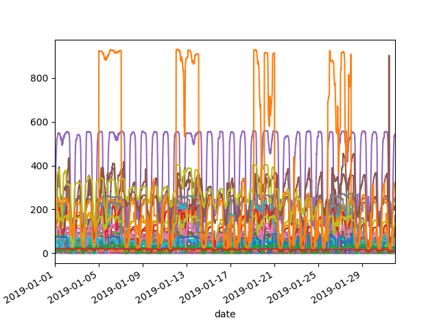

```python
df.plot(legend=False)
```

## Nettoyage des données

- estimation / correction données manquantes
- elimination colonnes bizarres
- normalisation

```python
trop_petits = set(df.columns[df.max() < 40])
bus = set(df.columns[["BUS" in nom for nom in df.columns]])
a_enlever = bus.union(trop_petits)

print("a enlever", a_enlever)

df = df.drop(a_enlever, 1)
df
```

```
a enlever {'PLATI', 'VISITATION', 'LES CARMES', 'PECHEURS BUS', 'ABBAYE', 'ECOLES', 'REGULATION BUS', 'DES OLIVIERS', 'GRIMALDI FORUM BUS', 'LES AGAVES', 'ATHENA', 'CHPG 1 (HAUT)'}
```

| date | ANNONCIADE | BOSIO | C.C.F. | CASINO | CHPG 2 (BAS) | CONDAMINE | COSTA | ECOLES RDC | ENGELIN | GARE | ... | PORT | QUAI ANTOINE 1ER | ROQUEVILLE | SQUARE GASTAUD | ST ANTOINE | ST CHARLES | ST LAURENT | ST NICOLAS | STADE | TESTIMONIO |
| --- | --- | --- | --- | --- | --- | --- | --- | --- | --- | --- | --- | --- | --- | --- | --- | --- | --- | --- | --- | --- | --- |
| 2018-12-31 23:58:45.513715 | 61.0 | 0.0 | 163.0 | 0.0 | 225.0 | 0.0 | 0.0 | 32.0 | 58.0 | 0.0 | ... | 7.0 | 0.0 | 16.0 | 0.0 | 36.0 | 1.0 | 0.0 | 68.0 | 139.0 | 0.0 |
| 2019-01-01 00:03:53.162553 | 61.0 | 0.0 | 161.0 | 0.0 | 225.0 | 0.0 | 0.0 | 31.0 | 58.0 | 0.0 | ... | 7.0 | 0.0 | 16.0 | 0.0 | 36.0 | 1.0 | 0.0 | 68.0 | 139.0 | 0.0 |
| 2019-01-01 00:08:55.503312 | 61.0 | 0.0 | 160.0 | 0.0 | 225.0 | 0.0 | 0.0 | 31.0 | 58.0 | 1.0 | ... | 6.0 | 0.0 | 16.0 | 0.0 | 36.0 | 1.0 | 0.0 | 69.0 | 137.0 | 0.0 |
| 2019-01-01 00:13:20.806756 | 61.0 | 0.0 | 160.0 | 0.0 | 225.0 | 0.0 | 0.0 | 31.0 | 58.0 | 1.0 | ... | 6.0 | 0.0 | 16.0 | 0.0 | 36.0 | 0.0 | 0.0 | 69.0 | 138.0 | 0.0 |
| 2019-01-01 00:18:25.333208 | 62.0 | 0.0 | 158.0 | 0.0 | 225.0 | 0.0 | 0.0 | 31.0 | 60.0 | 1.0 | ... | 7.0 | 0.0 | 16.0 | 0.0 | 36.0 | 1.0 | 0.0 | 69.0 | 138.0 | 0.0 |
| 2019-01-01 00:23:23.809532 | 62.0 | 0.0 | 152.0 | 29.0 | 223.0 | 3.0 | 0.0 | 31.0 | 60.0 | 2.0 | ... | 10.0 | 7.0 | 16.0 | 0.0 | 36.0 | 1.0 | 0.0 | 69.0 | 137.0 | 0.0 |
| 2019-01-01 00:28:27.377364 | 62.0 | 0.0 | 161.0 | 40.0 | 224.0 | 15.0 | 4.0 | 31.0 | 60.0 | 2.0 | ... | 12.0 | 17.0 | 17.0 | 2.0 | 36.0 | 6.0 | 0.0 | 68.0 | 136.0 | 0.0 |
| 2019-01-01 00:33:22.104059 | 64.0 | 0.0 | 176.0 | 46.0 | 224.0 | 19.0 | 6.0 | 31.0 | 60.0 | 9.0 | ... | 14.0 | 19.0 | 17.0 | 9.0 | 36.0 | 8.0 | 5.0 | 68.0 | 136.0 | 0.0 |
| 2019-01-01 00:38:29.046510 | 64.0 | 2.0 | 185.0 | 73.0 | 224.0 | 34.0 | 5.0 | 30.0 | 59.0 | 13.0 | ... | 16.0 | 28.0 | 17.0 | 10.0 | 36.0 | 14.0 | 8.0 | 68.0 | 136.0 | 0.0 |
| 2019-01-01 00:43:29.351093 | 65.0 | 4.0 | 200.0 | 79.0 | 224.0 | 41.0 | 7.0 | 29.0 | 61.0 | 23.0 | ... | 21.0 | 31.0 | 16.0 | 14.0 | 37.0 | 22.0 | 12.0 | 68.0 | 140.0 | 0.0 |
| 2019-01-01 00:48:36.611024 | 65.0 | 4.0 | 217.0 | 80.0 | 228.0 | 46.0 | 8.0 | 30.0 | 62.0 | 36.0 | ... | 23.0 | 40.0 | 16.0 | 14.0 | 37.0 | 29.0 | 16.0 | 68.0 | 142.0 | 0.0 |
| 2019-01-01 00:53:36.516809 | 66.0 | 6.0 | 241.0 | 81.0 | 230.0 | 55.0 | 5.0 | 31.0 | 63.0 | 46.0 | ... | 28.0 | 43.0 | 16.0 | 19.0 | 37.0 | 40.0 | 19.0 | 69.0 | 148.0 | 0.0 |
| 2019-01-01 00:58:38.622161 | 66.0 | 7.0 | 252.0 | 92.0 | 230.0 | 62.0 | 9.0 | 33.0 | 65.0 | 58.0 | ... | 30.0 | 49.0 | 18.0 | 15.0 | 37.0 | 52.0 | 22.0 | 69.0 | 152.0 | 0.0 |
| 2019-01-01 01:03:39.326647 | 67.0 | 7.0 | 269.0 | 93.0 | 230.0 | 74.0 | 11.0 | 33.0 | 67.0 | 65.0 | ... | 30.0 | 53.0 | 18.0 | 17.0 | 38.0 | 62.0 | 25.0 | 69.0 | 155.0 | 0.0 |
| 2019-01-01 01:08:57.683416 | 68.0 | 7.0 | 280.0 | 111.0 | 230.0 | 78.0 | 11.0 | 34.0 | 67.0 | 71.0 | ... | 31.0 | 57.0 | 19.0 | 12.0 | 39.0 | 66.0 | 26.0 | 69.0 | 157.0 | 0.0 |
| 2019-01-01 01:14:00.256048 | 70.0 | 11.0 | 289.0 | 116.0 | 231.0 | 86.0 | 13.0 | 34.0 | 69.0 | 81.0 | ... | 35.0 | 58.0 | 21.0 | 12.0 | 39.0 | 71.0 | 31.0 | 69.0 | 158.0 | 0.0 |
| 2019-01-01 01:18:09.696105 | 70.0 | 11.0 | 298.0 | 112.0 | 230.0 | 87.0 | 13.0 | 34.0 | 71.0 | 83.0 | ... | 37.0 | 60.0 | 23.0 | 14.0 | 39.0 | 75.0 | 31.0 | 70.0 | 159.0 | 0.0 |
| 2019-01-01 01:23:13.187660 | 72.0 | 11.0 | 308.0 | 113.0 | 230.0 | 91.0 | 13.0 | 35.0 | 71.0 | 92.0 | ... | 42.0 | 59.0 | 25.0 | 16.0 | 40.0 | 84.0 | 30.0 | 70.0 | 163.0 | 0.0 |
| 2019-01-01 01:28:12.490395 | 72.0 | 12.0 | 316.0 | 127.0 | 230.0 | 97.0 | 16.0 | 37.0 | 72.0 | 99.0 | ... | 44.0 | 67.0 | 28.0 | 20.0 | 41.0 | 93.0 | 29.0 | 70.0 | 167.0 | 0.0 |
| 2019-01-01 01:33:15.772777 | 73.0 | 14.0 | 334.0 | 131.0 | 230.0 | 107.0 | 17.0 | 36.0 | 73.0 | 104.0 | ... | 44.0 | 66.0 | 29.0 | 24.0 | 41.0 | 103.0 | 28.0 | 71.0 | 168.0 | 7.0 |
| 2019-01-01 01:38:10.126652 | 74.0 | 16.0 | 338.0 | 139.0 | 229.0 | 114.0 | 19.0 | 40.0 | 75.0 | 109.0 | ... | 51.0 | 70.0 | 31.0 | 26.0 | 42.0 | 109.0 | 28.0 | 71.0 | 172.0 | 7.0 |
| 2019-01-01 01:43:15.472919 | 77.0 | 18.0 | 352.0 | 146.0 | 233.0 | 120.0 | 20.0 | 43.0 | 77.0 | 115.0 | ... | 52.0 | 74.0 | 33.0 | 26.0 | 42.0 | 114.0 | 31.0 | 71.0 | 175.0 | 8.0 |
| 2019-01-01 01:48:16.924851 | 77.0 | 18.0 | 360.0 | 146.0 | 233.0 | 127.0 | 22.0 | 43.0 | 77.0 | 125.0 | ... | 52.0 | 72.0 | 33.0 | 27.0 | 42.0 | 120.0 | 34.0 | 71.0 | 182.0 | 8.0 |
| 2019-01-01 01:53:17.641957 | 77.0 | 20.0 | 369.0 | 146.0 | 233.0 | 131.0 | 25.0 | 43.0 | 77.0 | 132.0 | ... | 54.0 | 75.0 | 33.0 | 32.0 | 42.0 | 125.0 | 35.0 | 71.0 | 183.0 | 8.0 |
| 2019-01-01 01:58:43.727033 | 78.0 | 21.0 | 374.0 | 148.0 | 236.0 | 135.0 | 25.0 | 43.0 | 77.0 | 137.0 | ... | 54.0 | 79.0 | 35.0 | 37.0 | 42.0 | 130.0 | 34.0 | 72.0 | 184.0 | 8.0 |
| 2019-01-01 02:03:43.208523 | 79.0 | 23.0 | 383.0 | 156.0 | 235.0 | 140.0 | 26.0 | 43.0 | 78.0 | 138.0 | ... | 55.0 | 88.0 | 36.0 | 40.0 | 42.0 | 136.0 | 35.0 | 72.0 | 188.0 | 8.0 |
| 2019-01-01 02:08:52.602849 | 79.0 | 1.0 | 397.0 | 152.0 | 235.0 | 143.0 | 25.0 | 45.0 | 79.0 | 110.0 | ... | 55.0 | 95.0 | 37.0 | 46.0 | 42.0 | 139.0 | 36.0 | 72.0 | 190.0 | 8.0 |
| 2019-01-01 02:12:57.921321 | 79.0 | 1.0 | 406.0 | 157.0 | 235.0 | 148.0 | 25.0 | 45.0 | 83.0 | 113.0 | ... | 55.0 | 97.0 | 37.0 | 47.0 | 42.0 | 144.0 | 35.0 | 72.0 | 192.0 | 8.0 |
| 2019-01-01 02:17:57.898175 | 79.0 | 1.0 | 418.0 | 153.0 | 235.0 | 157.0 | 29.0 | 47.0 | 83.0 | 122.0 | ... | 56.0 | 102.0 | 37.0 | 56.0 | 42.0 | 144.0 | 35.0 | 72.0 | 193.0 | 8.0 |
| 2019-01-01 02:22:53.474961 | 79.0 | 1.0 | 421.0 | 156.0 | 234.0 | 162.0 | 29.0 | 47.0 | 83.0 | 127.0 | ... | 56.0 | 108.0 | 38.0 | 58.0 | 42.0 | 146.0 | 42.0 | 72.0 | 196.0 | 6.0 |
| ... | ... | ... | ... | ... | ... | ... | ... | ... | ... | ... | ... | ... | ... | ... | ... | ... | ... | ... | ... | ... | ... |
| 2019-01-31 21:27:46.206819 | 22.0 | 0.0 | 524.0 | 18.0 | 235.0 | 53.0 | 29.0 | 41.0 | 89.0 | 63.0 | ... | 9.0 | 45.0 | 55.0 | 32.0 | 69.0 | 124.0 | 26.0 | 27.0 | 288.0 | 9.0 |
| 2019-01-31 21:33:50.135226 | 22.0 | 0.0 | 528.0 | 15.0 | 235.0 | 54.0 | 29.0 | 42.0 | 90.0 | 63.0 | ... | 11.0 | 52.0 | 55.0 | 34.0 | 69.0 | 124.0 | 26.0 | 27.0 | 290.0 | 9.0 |
| 2019-01-31 21:38:47.066052 | 22.0 | 0.0 | 531.0 | 8.0 | 235.0 | 56.0 | 29.0 | 42.0 | 90.0 | 63.0 | ... | 11.0 | 57.0 | 55.0 | 37.0 | 69.0 | 124.0 | 27.0 | 27.0 | 293.0 | 11.0 |
| 2019-01-31 21:43:51.447938 | 22.0 | 0.0 | 532.0 | 12.0 | 237.0 | 57.0 | 29.0 | 42.0 | 90.0 | 65.0 | ... | 12.0 | 59.0 | 56.0 | 39.0 | 69.0 | 124.0 | 27.0 | 27.0 | 294.0 | 11.0 |
| 2019-01-31 21:48:57.912843 | 6.0 | 0.0 | 533.0 | 17.0 | 237.0 | 57.0 | 29.0 | 42.0 | 90.0 | 66.0 | ... | 12.0 | 61.0 | 55.0 | 42.0 | 69.0 | 126.0 | 26.0 | 27.0 | 295.0 | 12.0 |
| 2019-01-31 21:53:10.028467 | 5.0 | 0.0 | 532.0 | 17.0 | 238.0 | 58.0 | 29.0 | 43.0 | 90.0 | 66.0 | ... | 13.0 | 63.0 | 55.0 | 41.0 | 69.0 | 126.0 | 26.0 | 27.0 | 296.0 | 12.0 |
| 2019-01-31 21:58:11.571964 | 5.0 | 0.0 | 534.0 | 18.0 | 238.0 | 59.0 | 29.0 | 43.0 | 90.0 | 65.0 | ... | 14.0 | 64.0 | 53.0 | 42.0 | 69.0 | 127.0 | 27.0 | 27.0 | 297.0 | 12.0 |
| 2019-01-31 22:03:13.412295 | 7.0 | 0.0 | 536.0 | 19.0 | 243.0 | 60.0 | 28.0 | 43.0 | 90.0 | 66.0 | ... | 14.0 | 64.0 | 53.0 | 43.0 | 69.0 | 127.0 | 27.0 | 27.0 | 303.0 | 11.0 |
| 2019-01-31 22:08:15.514640 | 7.0 | 0.0 | 535.0 | 20.0 | 244.0 | 61.0 | 28.0 | 43.0 | 90.0 | 66.0 | ... | 22.0 | 67.0 | 53.0 | 43.0 | 70.0 | 127.0 | 27.0 | 27.0 | 304.0 | 11.0 |
| 2019-01-31 22:13:20.492405 | 7.0 | 0.0 | 539.0 | 23.0 | 245.0 | 62.0 | 28.0 | 44.0 | 90.0 | 67.0 | ... | 23.0 | 70.0 | 54.0 | 44.0 | 70.0 | 127.0 | 27.0 | 27.0 | 304.0 | 11.0 |
| 2019-01-31 22:18:23.078005 | 7.0 | 0.0 | 538.0 | 27.0 | 245.0 | 64.0 | 29.0 | 44.0 | 90.0 | 65.0 | ... | 23.0 | 70.0 | 54.0 | 46.0 | 72.0 | 127.0 | 28.0 | 27.0 | 305.0 | 11.0 |
| 2019-01-31 22:23:26.651440 | 7.0 | 0.0 | 539.0 | 28.0 | 246.0 | 64.0 | 29.0 | 44.0 | 91.0 | 66.0 | ... | 24.0 | 71.0 | 54.0 | 47.0 | 72.0 | 128.0 | 28.0 | 27.0 | 310.0 | 11.0 |
| 2019-01-31 22:28:26.148944 | 7.0 | 0.0 | 539.0 | 30.0 | 247.0 | 65.0 | 30.0 | 44.0 | 90.0 | 65.0 | ... | 26.0 | 73.0 | 55.0 | 49.0 | 72.0 | 127.0 | 31.0 | 27.0 | 311.0 | 18.0 |
| 2019-01-31 22:33:33.933291 | 7.0 | 0.0 | 540.0 | 30.0 | 249.0 | 39.0 | 30.0 | 44.0 | 90.0 | 65.0 | ... | 28.0 | 81.0 | 55.0 | 54.0 | 72.0 | 130.0 | 31.0 | 27.0 | 311.0 | 18.0 |
| 2019-01-31 22:38:37.469309 | 7.0 | 0.0 | 539.0 | 32.0 | 248.0 | 43.0 | 30.0 | 44.0 | 91.0 | 65.0 | ... | 27.0 | 80.0 | 55.0 | 56.0 | 72.0 | 131.0 | 30.0 | 27.0 | 314.0 | 17.0 |
| 2019-01-31 22:43:51.681951 | 7.0 | 0.0 | 538.0 | 31.0 | 248.0 | 43.0 | 30.0 | 37.0 | 91.0 | 66.0 | ... | 27.0 | 85.0 | 55.0 | 58.0 | 72.0 | 131.0 | 30.0 | 27.0 | 317.0 | 17.0 |
| 2019-01-31 22:47:47.382396 | 7.0 | 0.0 | 539.0 | 35.0 | 248.0 | 45.0 | 30.0 | 37.0 | 91.0 | 66.0 | ... | 29.0 | 91.0 | 55.0 | 61.0 | 71.0 | 131.0 | 31.0 | 27.0 | 319.0 | 17.0 |
| 2019-01-31 22:52:48.298390 | 7.0 | 0.0 | 540.0 | 36.0 | 249.0 | 47.0 | 30.0 | 37.0 | 91.0 | 66.0 | ... | 31.0 | 93.0 | 55.0 | 60.0 | 71.0 | 133.0 | 31.0 | 27.0 | 320.0 | 19.0 |
| 2019-01-31 22:57:51.937293 | 8.0 | 0.0 | 540.0 | 41.0 | 249.0 | 48.0 | 30.0 | 37.0 | 90.0 | 66.0 | ... | 31.0 | 101.0 | 55.0 | 63.0 | 71.0 | 133.0 | 31.0 | 27.0 | 321.0 | 19.0 |
| 2019-01-31 23:03:01.586139 | 8.0 | 0.0 | 541.0 | 70.0 | 250.0 | 48.0 | 30.0 | 38.0 | 90.0 | 66.0 | ... | 31.0 | 103.0 | 55.0 | 64.0 | 71.0 | 133.0 | 32.0 | 27.0 | 321.0 | 19.0 |
| 2019-01-31 23:08:00.045280 | 8.0 | 0.0 | 540.0 | 99.0 | 250.0 | 48.0 | 30.0 | 41.0 | 89.0 | 67.0 | ... | 33.0 | 109.0 | 56.0 | 64.0 | 71.0 | 133.0 | 34.0 | 27.0 | 322.0 | 22.0 |
| 2019-01-31 23:13:05.809609 | 9.0 | 0.0 | 541.0 | 112.0 | 251.0 | 48.0 | 31.0 | 41.0 | 89.0 | 67.0 | ... | 34.0 | 113.0 | 56.0 | 70.0 | 71.0 | 135.0 | 34.0 | 27.0 | 322.0 | 22.0 |
| 2019-01-31 23:18:08.733336 | 9.0 | 0.0 | 541.0 | 123.0 | 252.0 | 49.0 | 32.0 | 41.0 | 89.0 | 67.0 | ... | 36.0 | 115.0 | 56.0 | 71.0 | 71.0 | 138.0 | 35.0 | 27.0 | 322.0 | 23.0 |
| 2019-01-31 23:23:10.170335 | 10.0 | 0.0 | 540.0 | 138.0 | 252.0 | 49.0 | 32.0 | 41.0 | 90.0 | 68.0 | ... | 38.0 | 120.0 | 56.0 | 72.0 | 71.0 | 138.0 | 35.0 | 27.0 | 323.0 | 23.0 |
| 2019-01-31 23:28:23.002361 | 10.0 | 0.0 | 540.0 | 153.0 | 252.0 | 49.0 | 32.0 | 41.0 | 90.0 | 68.0 | ... | 40.0 | 127.0 | 58.0 | 72.0 | 71.0 | 140.0 | 36.0 | 27.0 | 323.0 | 22.0 |
| 2019-01-31 23:33:34.376227 | 10.0 | 0.0 | 541.0 | 157.0 | 251.0 | 49.0 | 32.0 | 42.0 | 91.0 | 68.0 | ... | 40.0 | 134.0 | 59.0 | 72.0 | 71.0 | 140.0 | 36.0 | 27.0 | 323.0 | 22.0 |
| 2019-01-31 23:38:44.117248 | 10.0 | 0.0 | 542.0 | 161.0 | 252.0 | 50.0 | 32.0 | 42.0 | 91.0 | 68.0 | ... | 40.0 | 135.0 | 59.0 | 72.0 | 71.0 | 140.0 | 36.0 | 27.0 | 322.0 | 23.0 |
| 2019-01-31 23:43:44.644075 | 10.0 | 0.0 | 541.0 | 162.0 | 252.0 | 51.0 | 32.0 | 42.0 | 91.0 | 68.0 | ... | 40.0 | 141.0 | 60.0 | 72.0 | 70.0 | 140.0 | 37.0 | 27.0 | 322.0 | 24.0 |
| 2019-01-31 23:48:59.779344 | 10.0 | 0.0 | 542.0 | 167.0 | 252.0 | 51.0 | 32.0 | 42.0 | 91.0 | 68.0 | ... | 40.0 | 146.0 | 60.0 | 72.0 | 70.0 | 141.0 | 37.0 | 27.0 | 322.0 | 24.0 |
| 2019-01-31 23:54:01.214992 | 10.0 | 0.0 | 543.0 | 172.0 | 252.0 | 51.0 | 32.0 | 42.0 | 91.0 | 68.0 | ... | 40.0 | 148.0 | 60.0 | 72.0 | 70.0 | 141.0 | 37.0 | 27.0 | 314.0 | 24.0 |

8928 rows × 32 columns

### Etude des valeurs manquantes

```python
nb_nan = df.isna().sum().sum()
print("Nombre de valeurs manquantes :", nb_nan)
```

```
Nombre de valeurs manquantes : 2243
```

```python
# analyse par ligne et colonnes
df.isnull().sum(axis=0).sort_values()
```

```
LARVOTTO             63
QUAI ANTOINE 1ER     63
CHPG 2 (BAS)         63
PECHEURS             63
LOUIS II             63
ENGELIN              63
LA DIGUE             63
JARDIN EXOTIQUE      63
BOSIO                64
ST CHARLES           64
GARE                 64
OSTENDE              65
TESTIMONIO           65
COSTA                66
STADE                67
C.C.F.               67
PAPALINS             67
CONDAMINE            67
SQUARE GASTAUD       67
ST NICOLAS           68
PLACE D ARMES        68
ECOLES RDC           69
HELIPORT             69
PORT                 73
ANNONCIADE           74
MOULINS              74
GRIMALDI FORUM       74
LA COLLE             76
CASINO               81
ROQUEVILLE           92
ST ANTOINE           97
ST LAURENT          101
dtype: int64
```

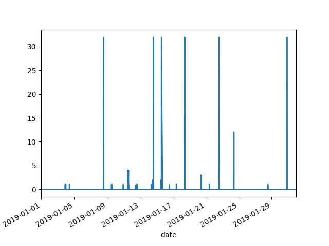

```python
t = df.isnull().sum(axis=1)
plt.figure()
t.plot()
plt.show()
```

#### Downsampling et nettoyage

```python
df = df.resample('H').mean()
df = df.interpolate(how='linear')
df
```

| date | ANNONCIADE | BOSIO | C.C.F. | CASINO | CHPG 2 (BAS) | CONDAMINE | COSTA | ECOLES RDC | ENGELIN | GARE | ... | PORT | QUAI ANTOINE 1ER | ROQUEVILLE | SQUARE GASTAUD | ST ANTOINE | ST CHARLES | ST LAURENT | ST NICOLAS | STADE | TESTIMONIO |
| --- | --- | --- | --- | --- | --- | --- | --- | --- | --- | --- | --- | --- | --- | --- | --- | --- | --- | --- | --- | --- | --- |
| 2018-12-31 23:00:00 | 61.000000 | 0.000000 | 163.000000 | 0.000000 | 225.000000 | 0.000000 | 0.000000 | 32.000000 | 58.000000 | 0.000000 | ... | 7.000000 | 0.000000 | 16.000000 | 0.000000 | 36.000000 | 1.000000 | 0.000000 | 68.000000 | 139.000000 | 0.000000 |
| 2019-01-01 00:00:00 | 63.250000 | 1.916667 | 185.250000 | 43.333333 | 225.583333 | 22.916667 | 3.666667 | 30.833333 | 60.333333 | 16.000000 | ... | 15.000000 | 19.500000 | 16.416667 | 6.916667 | 36.333333 | 14.583333 | 6.833333 | 68.500000 | 139.916667 | 0.000000 |
| 2019-01-01 01:00:00 | 72.916667 | 13.833333 | 323.916667 | 127.333333 | 231.250000 | 103.916667 | 17.083333 | 37.916667 | 72.750000 | 101.083333 | ... | 43.833333 | 65.833333 | 27.333333 | 21.916667 | 40.583333 | 96.000000 | 30.166667 | 70.333333 | 168.583333 | 3.833333 |
| 2019-01-01 02:00:00 | 78.833333 | 5.750000 | 427.666667 | 158.166667 | 234.833333 | 165.416667 | 29.916667 | 46.583333 | 83.750000 | 132.000000 | ... | 57.500000 | 110.250000 | 39.583333 | 59.583333 | 42.750000 | 154.666667 | 38.166667 | 72.416667 | 197.666667 | 8.083333 |
| 2019-01-01 03:00:00 | 79.833333 | 10.000000 | 487.250000 | 212.166667 | 236.166667 | 164.000000 | 44.416667 | 52.000000 | 87.916667 | 165.833333 | ... | 68.750000 | 133.583333 | 44.500000 | 83.500000 | 46.750000 | 184.416667 | 36.916667 | 73.750000 | 211.166667 | 10.000000 |
| 2019-01-01 04:00:00 | 81.000000 | 12.000000 | 520.166667 | 272.416667 | 239.416667 | 172.083333 | 53.750000 | 53.833333 | 91.250000 | 187.000000 | ... | 75.416667 | 144.583333 | 45.250000 | 99.333333 | 48.083333 | 201.250000 | 44.166667 | 73.083333 | 225.916667 | 10.916667 |
| 2019-01-01 05:00:00 | 81.166667 | 12.000000 | 533.500000 | 309.500000 | 242.083333 | 179.833333 | 58.750000 | 54.666667 | 91.416667 | 198.333333 | ... | 78.416667 | 172.500000 | 45.833333 | 114.416667 | 48.916667 | 208.000000 | 49.916667 | 73.250000 | 231.583333 | 12.583333 |
| 2019-01-01 06:00:00 | 81.666667 | 12.000000 | 544.500000 | 354.666667 | 227.583333 | 180.750000 | 58.500000 | 54.833333 | 91.000000 | 199.500000 | ... | 80.583333 | 190.416667 | 46.000000 | 122.250000 | 50.000000 | 156.416667 | 60.083333 | 73.750000 | 234.000000 | 11.416667 |
| 2019-01-01 07:00:00 | 81.000000 | 10.666667 | 548.166667 | 370.833333 | 225.750000 | 181.666667 | 59.583333 | 55.000000 | 90.916667 | 199.750000 | ... | 82.083333 | 197.750000 | 45.750000 | 123.166667 | 50.000000 | 158.916667 | 62.000000 | 72.916667 | 233.000000 | 8.000000 |
| 2019-01-01 08:00:00 | 80.833333 | 10.000000 | 548.916667 | 374.416667 | 223.500000 | 132.333333 | 60.583333 | 54.416667 | 90.833333 | 196.583333 | ... | 83.416667 | 206.583333 | 47.000000 | 120.333333 | 50.000000 | 159.000000 | 62.666667 | 72.833333 | 233.666667 | 9.583333 |
| 2019-01-01 09:00:00 | 80.166667 | 10.000000 | 547.416667 | 374.166667 | 215.583333 | 63.750000 | 61.583333 | 53.666667 | 90.583333 | 199.833333 | ... | 83.750000 | 209.000000 | 48.000000 | 112.833333 | 50.416667 | 159.416667 | 62.750000 | 73.000000 | 233.250000 | 10.333333 |
| 2019-01-01 10:00:00 | 81.000000 | 10.000000 | 543.000000 | 352.250000 | 207.916667 | 60.250000 | 65.166667 | 54.833333 | 90.833333 | 200.916667 | ... | 85.166667 | 199.083333 | 50.083333 | 107.750000 | 50.000000 | 161.083333 | 55.916667 | 72.416667 | 231.916667 | 12.000000 |
| 2019-01-01 11:00:00 | 81.500000 | 12.916667 | 536.416667 | 280.916667 | 191.833333 | 48.833333 | 61.750000 | 55.000000 | 89.916667 | 202.166667 | ... | 83.416667 | 177.916667 | 51.500000 | 100.250000 | 50.000000 | 157.166667 | 51.000000 | 73.000000 | 230.750000 | 9.000000 |
| 2019-01-01 12:00:00 | 83.000000 | 13.000000 | 529.166667 | 169.500000 | 167.916667 | 138.166667 | 58.750000 | 54.833333 | 89.333333 | 198.500000 | ... | 80.333333 | 130.333333 | 53.000000 | 63.333333 | 47.916667 | 154.333333 | 43.750000 | 73.000000 | 229.250000 | 9.250000 |
| 2019-01-01 13:00:00 | 83.500000 | 12.416667 | 521.333333 | 67.750000 | 163.166667 | 129.416667 | 51.583333 | 55.666667 | 89.250000 | 200.500000 | ... | 75.750000 | 52.833333 | 53.500000 | 28.083333 | 46.583333 | 151.416667 | 32.416667 | 74.166667 | 225.750000 | 5.500000 |
| 2019-01-01 14:00:00 | 84.000000 | 11.750000 | 514.916667 | 10.916667 | 149.250000 | 107.416667 | 46.250000 | 55.000000 | 90.750000 | 199.833333 | ... | 70.083333 | 3.083333 | 53.666667 | 8.666667 | 44.166667 | 153.000000 | 26.666667 | 75.000000 | 224.000000 | 4.750000 |
| 2019-01-01 15:00:00 | 83.666667 | 10.666667 | 502.750000 | 7.166667 | 130.250000 | 69.166667 | 40.416667 | 52.583333 | 91.416667 | 197.750000 | ... | 72.750000 | 1.666667 | 53.833333 | 1.250000 | 44.500000 | 152.166667 | 28.916667 | 75.000000 | 222.166667 | 4.500000 |
| 2019-01-01 16:00:00 | 84.750000 | 11.583333 | 498.333333 | 4.333333 | 136.333333 | 65.250000 | 51.166667 | 53.916667 | 87.000000 | 196.166667 | ... | 80.250000 | 3.000000 | 48.583333 | 2.666667 | 47.750000 | 146.500000 | 43.000000 | 74.000000 | 225.750000 | 8.833333 |
| 2019-01-01 17:00:00 | 84.833333 | 11.833333 | 508.250000 | 10.666667 | 156.750000 | 88.583333 | 45.916667 | 56.833333 | 84.500000 | 196.583333 | ... | 82.916667 | 6.000000 | 46.833333 | 3.250000 | 50.500000 | 148.250000 | 42.000000 | 74.000000 | 227.833333 | 11.666667 |
| 2019-01-01 18:00:00 | 85.500000 | 12.833333 | 523.750000 | 34.416667 | 174.500000 | 134.083333 | 38.583333 | 58.416667 | 82.500000 | 204.666667 | ... | 85.833333 | 34.166667 | 47.333333 | 16.916667 | 53.083333 | 149.000000 | 59.166667 | 72.083333 | 229.000000 | 13.583333 |
| 2019-01-01 19:00:00 | 86.166667 | 13.500000 | 530.833333 | 89.750000 | 198.083333 | 155.416667 | 47.750000 | 59.000000 | 84.916667 | 208.833333 | ... | 85.833333 | 77.500000 | 50.166667 | 48.333333 | 52.166667 | 159.666667 | 66.666667 | 73.916667 | 231.916667 | 10.416667 |
| 2019-01-01 20:00:00 | 87.000000 | 14.000000 | 536.916667 | 135.083333 | 209.416667 | 129.500000 | 33.916667 | 58.583333 | 90.166667 | 216.750000 | ... | 81.750000 | 106.083333 | 50.666667 | 56.583333 | 52.833333 | 163.333333 | 75.000000 | 74.000000 | 231.166667 | 12.250000 |
| 2019-01-01 21:00:00 | 86.333333 | 6.250000 | 541.833333 | 157.250000 | 218.000000 | 54.833333 | 39.583333 | 59.000000 | 93.000000 | 68.250000 | ... | 76.416667 | 135.416667 | 51.166667 | 72.000000 | 54.000000 | 164.833333 | 77.166667 | 73.750000 | 233.166667 | 14.666667 |
| 2019-01-01 22:00:00 | 83.000000 | 7.000000 | 546.333333 | 161.833333 | 228.500000 | 60.666667 | 41.083333 | 58.916667 | 93.166667 | 66.833333 | ... | 78.750000 | 167.250000 | 53.000000 | 88.833333 | 54.000000 | 167.250000 | 77.916667 | 74.000000 | 234.833333 | 12.000000 |
| 2019-01-01 23:00:00 | 83.000000 | 6.083333 | 548.416667 | 186.833333 | 228.750000 | 64.583333 | 42.916667 | 58.250000 | 91.166667 | 68.500000 | ... | 82.916667 | 186.750000 | 54.416667 | 97.750000 | 54.000000 | 169.500000 | 81.750000 | 74.000000 | 234.000000 | 13.083333 |
| 2019-01-02 00:00:00 | 82.750000 | 6.000000 | 549.333333 | 236.583333 | 231.916667 | 64.500000 | 43.000000 | 58.916667 | 90.833333 | 72.750000 | ... | 81.583333 | 195.416667 | 55.000000 | 88.333333 | 54.000000 | 170.833333 | 73.000000 | 73.916667 | 235.583333 | 16.000000 |
| 2019-01-02 01:00:00 | 83.000000 | 6.000000 | 555.000000 | 305.250000 | 236.500000 | 65.000000 | 48.166667 | 59.000000 | 91.166667 | 70.916667 | ... | 43.000000 | 189.333333 | 55.333333 | 81.000000 | 54.083333 | 164.833333 | 64.250000 | 74.000000 | 237.333333 | 15.583333 |
| 2019-01-02 02:00:00 | 83.000000 | 6.000000 | 554.916667 | 345.833333 | 239.250000 | 65.000000 | 50.333333 | 59.000000 | 92.666667 | 70.000000 | ... | 43.000000 | 173.416667 | 55.583333 | 81.000000 | 55.000000 | 149.333333 | 65.416667 | 40.583333 | 235.500000 | 14.916667 |
| 2019-01-02 03:00:00 | 82.750000 | 5.750000 | 554.666667 | 367.666667 | 240.083333 | 65.833333 | 50.750000 | 58.833333 | 93.000000 | 69.083333 | ... | 44.000000 | 173.000000 | 56.000000 | 81.500000 | 54.833333 | 148.666667 | 67.000000 | 24.000000 | 235.416667 | 15.000000 |
| 2019-01-02 04:00:00 | 83.000000 | 5.000000 | 553.750000 | 381.916667 | 241.000000 | 67.000000 | 51.000000 | 59.000000 | 93.000000 | 69.083333 | ... | 44.000000 | 172.666667 | 56.000000 | 82.000000 | 54.083333 | 171.916667 | 67.250000 | 23.416667 | 234.666667 | 15.000000 |
| ... | ... | ... | ... | ... | ... | ... | ... | ... | ... | ... | ... | ... | ... | ... | ... | ... | ... | ... | ... | ... | ... |
| 2019-01-30 18:00:00 | 38.333333 | 0.000000 | 229.166667 | 207.416667 | 177.416667 | 19.916667 | 3.833333 | 37.666667 | 62.833333 | 70.750000 | ... | 23.916667 | 87.083333 | 36.916667 | 59.583333 | 50.250000 | 69.166667 | 35.083333 | 21.000000 | 174.166667 | 5.666667 |
| 2019-01-30 19:00:00 | 40.916667 | 0.000000 | 359.666667 | 268.500000 | 212.666667 | 15.333333 | 7.500000 | 42.166667 | 74.416667 | 69.750000 | ... | 16.000000 | 73.583333 | 46.166667 | 59.916667 | 61.666667 | 103.833333 | 52.250000 | 21.500000 | 233.750000 | 6.166667 |
| 2019-01-30 20:00:00 | 43.666667 | 0.000000 | 457.750000 | 287.916667 | 238.000000 | 29.250000 | 12.666667 | 41.083333 | 78.000000 | 76.416667 | ... | 7.416667 | 63.166667 | 50.000000 | 58.833333 | 69.416667 | 130.666667 | 55.416667 | 22.000000 | 275.166667 | 8.000000 |
| 2019-01-30 21:00:00 | 18.454545 | 0.000000 | 512.545455 | 290.090909 | 243.272727 | 43.545455 | 15.636364 | 41.818182 | 79.545455 | 79.272727 | ... | 7.909091 | 70.272727 | 54.454545 | 66.272727 | 73.909091 | 138.636364 | 56.727273 | 24.909091 | 292.909091 | 9.454545 |
| 2019-01-30 22:00:00 | 13.916667 | 0.000000 | 524.416667 | 298.416667 | 249.250000 | 51.416667 | 16.083333 | 43.750000 | 80.250000 | 81.583333 | ... | 20.333333 | 87.666667 | 63.333333 | 79.000000 | 79.666667 | 140.750000 | 62.583333 | 26.000000 | 308.750000 | 14.000000 |
| 2019-01-30 23:00:00 | 15.000000 | 0.000000 | 527.833333 | 310.750000 | 252.750000 | 59.250000 | 19.583333 | 45.000000 | 79.666667 | 84.000000 | ... | 32.833333 | 112.750000 | 63.916667 | 81.166667 | 80.833333 | 142.833333 | 69.500000 | 26.000000 | 314.833333 | 21.500000 |
| 2019-01-31 00:00:00 | 14.750000 | 0.000000 | 548.416667 | 323.416667 | 255.166667 | 61.666667 | 20.000000 | 46.000000 | 79.833333 | 73.500000 | ... | 36.916667 | 122.583333 | 64.000000 | 83.916667 | 80.000000 | 143.000000 | 71.750000 | 26.000000 | 276.833333 | 26.416667 |
| 2019-01-31 01:00:00 | 15.000000 | 0.000000 | 555.000000 | 332.666667 | 250.583333 | 61.500000 | 17.333333 | 46.000000 | 79.000000 | 60.750000 | ... | 40.000000 | 125.250000 | 63.916667 | 85.666667 | 80.000000 | 143.000000 | 71.750000 | 26.000000 | 232.583333 | 26.833333 |
| 2019-01-31 02:00:00 | 15.000000 | 0.000000 | 554.833333 | 342.916667 | 247.916667 | 62.000000 | 17.000000 | 42.583333 | 78.833333 | 60.500000 | ... | 40.000000 | 127.000000 | 63.583333 | 86.000000 | 76.583333 | 143.916667 | 71.916667 | 25.916667 | 231.250000 | 27.000000 |
| 2019-01-31 03:00:00 | 14.666667 | 0.000000 | 554.833333 | 352.583333 | 247.416667 | 62.000000 | 16.833333 | 42.000000 | 79.000000 | 60.083333 | ... | 40.000000 | 127.000000 | 64.000000 | 86.000000 | 71.000000 | 144.583333 | 72.000000 | 25.916667 | 231.333333 | 26.916667 |
| 2019-01-31 04:00:00 | 14.833333 | 0.000000 | 554.000000 | 352.750000 | 247.000000 | 62.000000 | 17.000000 | 42.000000 | 79.000000 | 59.166667 | ... | 40.000000 | 127.000000 | 63.916667 | 86.000000 | 70.000000 | 148.500000 | 48.166667 | 24.916667 | 230.750000 | 27.000000 |
| 2019-01-31 05:00:00 | 14.000000 | 0.000000 | 553.916667 | 357.833333 | 247.750000 | 61.250000 | 15.583333 | 41.833333 | 78.750000 | 60.750000 | ... | 39.583333 | 126.166667 | 63.750000 | 86.000000 | 67.500000 | 147.750000 | 44.583333 | 24.833333 | 230.000000 | 27.416667 |
| 2019-01-31 06:00:00 | 12.916667 | 0.000000 | 551.416667 | 353.500000 | 237.500000 | 61.333333 | 12.916667 | 41.083333 | 78.083333 | 60.083333 | ... | 40.833333 | 121.916667 | 61.416667 | 83.166667 | 63.166667 | 146.000000 | 42.833333 | 25.000000 | 223.666667 | 27.333333 |
| 2019-01-31 07:00:00 | 9.166667 | 0.000000 | 535.833333 | 241.583333 | 211.000000 | 59.500000 | 8.416667 | 38.833333 | 70.250000 | 57.250000 | ... | 37.500000 | 115.333333 | 46.833333 | 67.416667 | 53.833333 | 135.583333 | 34.333333 | 24.416667 | 180.500000 | 19.750000 |
| 2019-01-31 08:00:00 | 5.000000 | 0.000000 | 449.250000 | 138.750000 | 156.000000 | 52.583333 | 3.083333 | 25.000000 | 57.166667 | 46.583333 | ... | 24.166667 | 80.500000 | 21.083333 | 34.333333 | 37.416667 | 99.250000 | 6.916667 | 23.333333 | 94.750000 | 4.916667 |
| 2019-01-31 09:00:00 | 0.750000 | 0.000000 | 302.416667 | 54.916667 | 86.000000 | 44.500000 | 3.333333 | 24.666667 | 49.000000 | 34.916667 | ... | 6.083333 | 65.833333 | 0.750000 | 3.666667 | 25.416667 | 30.416667 | 0.000000 | 23.333333 | 14.500000 | 0.750000 |
| 2019-01-31 10:00:00 | 1.666667 | 0.000000 | 194.666667 | 0.000000 | 42.000000 | 28.000000 | 5.166667 | 14.083333 | 50.083333 | 22.750000 | ... | 0.500000 | 54.916667 | 525.916667 | 1.083333 | 23.416667 | 3.333333 | 0.083333 | 19.083333 | 2.416667 | 0.333333 |
| 2019-01-31 11:00:00 | 5.000000 | 0.000000 | 186.333333 | 0.000000 | 24.666667 | 19.333333 | 2.500000 | 8.416667 | 50.416667 | 15.583333 | ... | 0.916667 | 45.416667 | 75.750000 | 0.416667 | 22.166667 | 1.250000 | 0.250000 | 16.083333 | 4.250000 | 0.833333 |
| 2019-01-31 12:00:00 | 5.166667 | 0.000000 | 198.750000 | 0.000000 | 68.083333 | 10.166667 | 2.750000 | 15.333333 | 68.500000 | 14.666667 | ... | 0.250000 | 24.666667 | 1.166667 | 0.083333 | 14.666667 | 7.583333 | 0.750000 | 16.666667 | 9.166667 | 0.333333 |
| 2019-01-31 13:00:00 | 3.750000 | 0.000000 | 224.416667 | 0.000000 | 40.166667 | 9.083333 | 0.416667 | 16.916667 | 63.666667 | 27.083333 | ... | 0.333333 | 16.166667 | 0.000000 | 3.500000 | 13.583333 | 0.166667 | 0.000000 | 19.416667 | 30.750000 | 0.166667 |
| 2019-01-31 14:00:00 | 5.500000 | 0.000000 | 189.916667 | 0.000000 | 10.500000 | 8.416667 | 0.333333 | 14.833333 | 56.250000 | 23.250000 | ... | 1.916667 | 25.750000 | 4.500000 | 0.416667 | 15.500000 | 0.833333 | 0.000000 | 21.000000 | 29.000000 | 1.583333 |
| 2019-01-31 15:00:00 | 8.750000 | 0.000000 | 128.500000 | 0.000000 | 18.000000 | 6.916667 | 0.666667 | 14.833333 | 54.333333 | 24.333333 | ... | 7.416667 | 27.750000 | 2.916667 | 2.250000 | 16.333333 | 1.583333 | 0.333333 | 20.500000 | 30.333333 | 3.833333 |
| 2019-01-31 16:00:00 | 16.166667 | 0.000000 | 147.833333 | 0.000000 | 58.916667 | 16.500000 | 2.000000 | 11.750000 | 59.166667 | 32.000000 | ... | 12.500000 | 47.250000 | 9.916667 | 15.833333 | 21.166667 | 5.000000 | 0.916667 | 22.916667 | 64.166667 | 4.166667 |
| 2019-01-31 17:00:00 | 10.583333 | 0.000000 | 162.666667 | 39.333333 | 133.916667 | 25.750000 | 6.583333 | 30.583333 | 58.916667 | 46.000000 | ... | 25.666667 | 63.500000 | 28.416667 | 31.666667 | 30.583333 | 13.083333 | 2.583333 | 22.750000 | 105.166667 | 5.166667 |
| 2019-01-31 18:00:00 | 8.500000 | 0.000000 | 226.333333 | 83.333333 | 182.333333 | 8.750000 | 12.666667 | 43.583333 | 71.000000 | 56.083333 | ... | 23.500000 | 76.833333 | 40.500000 | 39.250000 | 37.916667 | 54.500000 | 8.833333 | 23.166667 | 182.500000 | 5.250000 |
| 2019-01-31 19:00:00 | 16.250000 | 0.000000 | 350.166667 | 65.416667 | 208.750000 | 12.750000 | 16.000000 | 44.500000 | 83.666667 | 55.333333 | ... | 14.250000 | 83.250000 | 50.500000 | 33.500000 | 50.166667 | 89.166667 | 17.000000 | 25.750000 | 220.333333 | 8.666667 |
| 2019-01-31 20:00:00 | 20.583333 | 0.000000 | 463.583333 | 14.250000 | 229.416667 | 16.750000 | 24.416667 | 40.916667 | 86.583333 | 58.250000 | ... | 6.416667 | 43.500000 | 52.333333 | 17.916667 | 64.833333 | 111.166667 | 19.500000 | 27.000000 | 257.083333 | 8.416667 |
| 2019-01-31 21:00:00 | 17.833333 | 0.000000 | 523.416667 | 14.500000 | 234.833333 | 48.833333 | 29.000000 | 41.833333 | 89.166667 | 63.416667 | ... | 10.583333 | 51.583333 | 54.666667 | 33.250000 | 68.583333 | 124.083333 | 25.583333 | 27.000000 | 288.833333 | 9.666667 |
| 2019-01-31 22:00:00 | 7.083333 | 0.000000 | 538.500000 | 29.333333 | 246.750000 | 53.416667 | 29.333333 | 41.500000 | 90.416667 | 65.750000 | ... | 25.416667 | 78.833333 | 54.416667 | 52.000000 | 71.166667 | 129.333333 | 29.333333 | 27.000000 | 311.583333 | 15.000000 |
| 2019-01-31 23:00:00 | 9.454545 | 0.000000 | 541.090909 | 137.636364 | 251.454545 | 49.363636 | 31.545455 | 41.181818 | 90.181818 | 67.545455 | ... | 37.454545 | 126.454545 | 57.727273 | 70.272727 | 70.727273 | 138.090909 | 35.363636 | 27.000000 | 321.454545 | 22.545455 |

745 rows × 32 columns

#### Normalisation des échelles

- grandes différences dans les tailles des parkings
- on va diviser chaque parking par son nombre de place total

[figure not shown]

```python
pourcentage_libre = df.apply(lambda x: x / x.max())
pourcentage_libre.plot(legend=False)
```

## Place aux questions métier

- les parkings sont-ils suffisamment grands ?
- y-a-t'il une récurrence temporelle au niveau des places libres ?
- par quel endroit les travailleurs arrivent-ils ?
- les patterns sont-ils les même en été et en hiver ?
- ...

#### Les parkings sont-ils assez grands ?

On regarde si a un moment on a plus du tout de places libres.

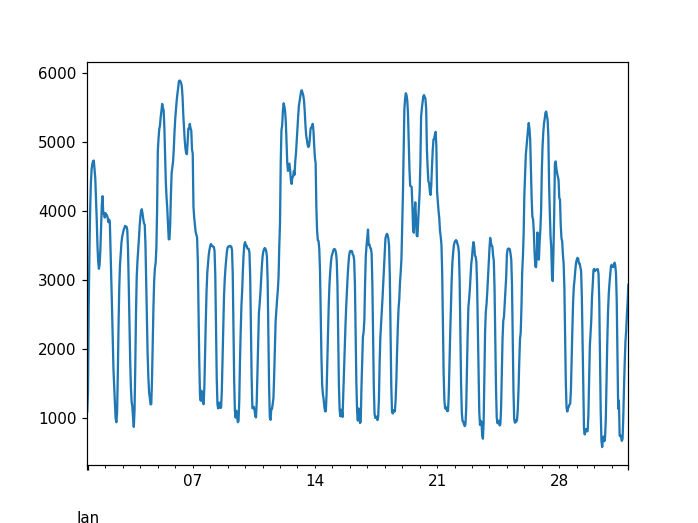

```python
total_places_libres = df.sum(axis=1)
total_places_libres.describe()
plt.figure()
total_places_libres.plot()
plt.show()
```

#### Les parkings suivent-ils les même tendances ?

Sont-ils tous quasiment plein à 8h du mat et quasiment vide la nuit ?

```python
coeff_variation = df.std() / df.mean()
coeff_variation.dropna().sort_values()
```

```
ENGELIN             0.162077
GRIMALDI FORUM      0.283716
MOULINS             0.378335
LOUIS II            0.408160
LARVOTTO            0.429566
PECHEURS            0.430500
CHPG 2 (BAS)        0.444560
C.C.F.              0.447256
JARDIN EXOTIQUE     0.474097
ST CHARLES          0.547712
ECOLES RDC          0.556609
QUAI ANTOINE 1ER    0.607473
OSTENDE             0.641370
CASINO              0.655930
CONDAMINE           0.659389
TESTIMONIO          0.662062
GARE                0.673498
SQUARE GASTAUD      0.673546
LA COLLE            0.692405
ROQUEVILLE          0.701028
ST LAURENT          0.703451
LA DIGUE            0.758203
PLACE D ARMES       0.759196
ST NICOLAS          0.761251
PORT                0.772705
COSTA               0.780515
ANNONCIADE          0.883506
ST ANTOINE          0.982644
STADE               0.984279
PAPALINS            1.023247
HELIPORT            1.158611
BOSIO               1.555401
dtype: float64
```

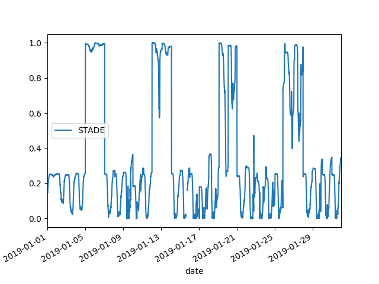

```python
#pourcentage_libre[["ENGELIN", "PAPALINS", "STADE", "BOSIO"]].plot()
pourcentage_libre[["STADE"]].plot()
```

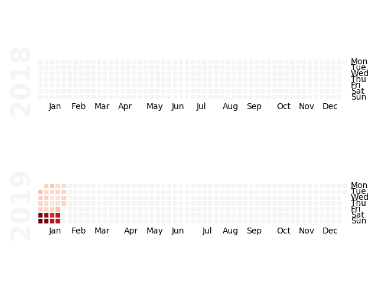

```python
import calmap
calmap.calendarplot(df.STADE)
plt.show()
```

## Conclusions

- python / pandas / matplotlib => facilitent l'analyse de données
  - change la donne par rapport à `numpy` de base
- données > tout le reste
  - origine
  - déterminer la volonté du fournisseur
    - quels sont les biais ?
  - le reste consiste à maitriser les outils (mathématiques, techniques...)
- importance de comprendre les aspects métiers
  - pas de "balles en argent" en data science
- toujours chercher à répondre à des questions
  - sinon papillonage
  - *computer disease* (R. Feynman): “Anybody who works with computers knows about [it]. It's a very serious disease and it interferes completely with the work. The trouble with computers is that you 'play' with them!”

## Merci

### Questions ?

## Ressources utilisées

- https://www.livressedesmots.com/wp-content/uploads/2016/03/Kung-Fu-Panda-3-1200x675.jpg
- https://proxy.duckduckgo.com/iu/\?u\=http%3A%2F%2Fi.ytimg.com%2Fvi%2FXhXWPFnQ0Tk%2Fmaxresdefault.jpg\&f\=1
- https://cdn-images-1.medium.com/max/1600/1\*tvrJ2T5okSzZIEuOymEpXQ.jpeg
- https://cdn.cnn.com/cnnnext/dam/assets/171212114951-monaco-aerial-view.jpg
- https://upload.wikimedia.org/wikipedia/commons/4/4d/Monaco-carte.jpg
- https://upload.wikimedia.org/wikipedia/commons/e/e4/Monaco_wards_color.png\?uselang\=fr
- http://fr.maps-monaco.com/img/1200/monaco-parking-carte.jpg